# Hien Duy Nguyen

19 September, 2025

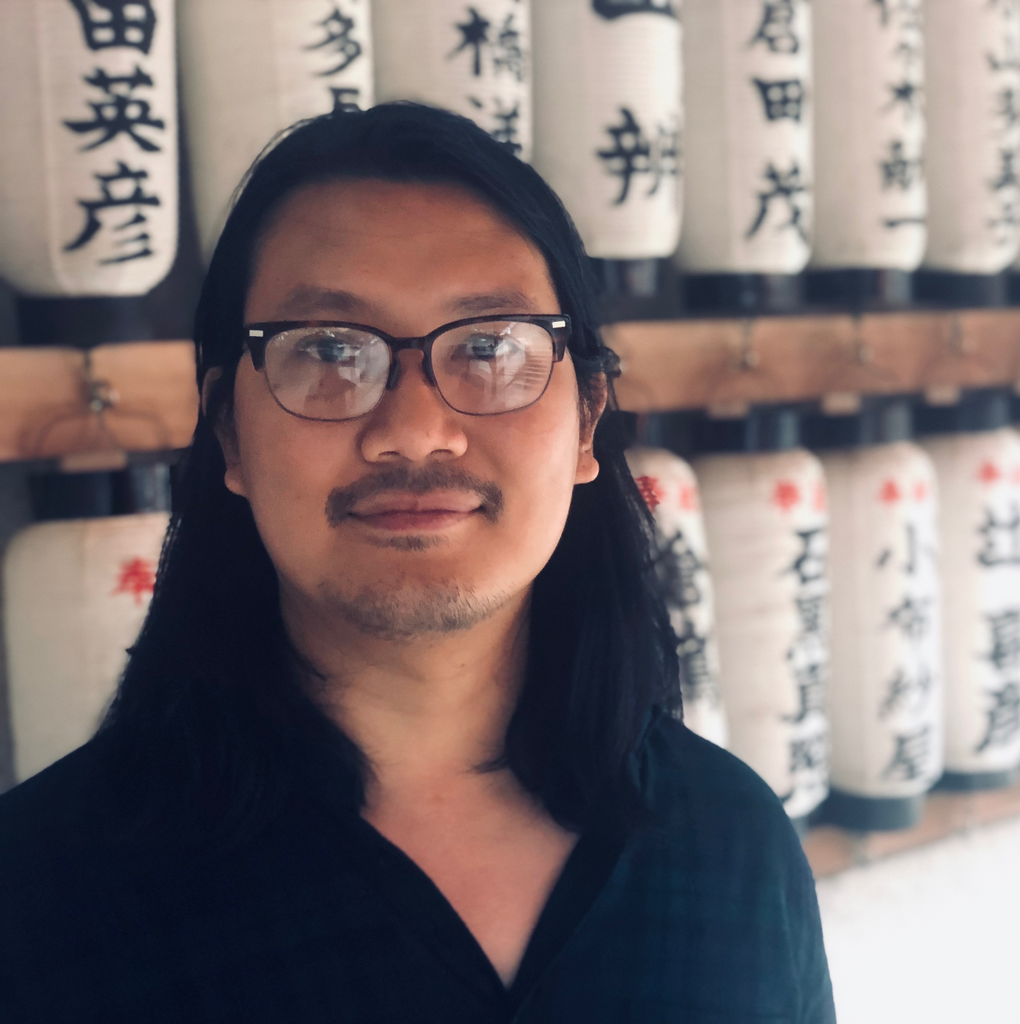

# Hien Duy Nguyen

Associate Professor, La Trobe University · Professor (IMI), Kyushu University

**Email:** h.nguyen5@latrobe.edu.au · **CV:** [Download](https://github.com/hiendn/CV/blob/master/Master_CV.pdf)

[ORCID: 0000-0002-9958-432X](https://orcid.org/0000-0002-9958-432X) · [ResearchGate](https://www.researchgate.net/profile/Hien_Nguyen25) · [GitHub](https://github.com/hiendn)

## Contact Details

Primary affiliation

Dr. Hien Duy Nguyen  
Associate Professor  
School of Computing, Engineering and Mathematical Sciences  
La Trobe University  
Bundoora, Victoria, Australia

Profiles & links

- h.nguyen5@latrobe.edu.au
- [ORCID: 0000-0002-9958-432X](https://orcid.org/0000-0002-9958-432X)
- [ResearchGate](https://www.researchgate.net/profile/Hien_Nguyen25)
- [GitHub](https://github.com/hiendn)

## Brief Bio

Hien Nguyen holds dual positions as an Associate Professor at La Trobe University in Australia and a Professor at the Institute of Mathematics for Industry at Kyushu University in Japan. His role focuses on building collaborative relationships between the two institutions and the two countries at large to foster new innovative research in mathematical and computational statistics, as well as the applications of such developments. Hien also holds an Honorary Associate Professorship at his Alma Mater, the University of Queensland in Brisbane, Australia, where he continues to supervise students.

Hien has a strong interest in the research of computational statistics and its interaction with the fields of machine learning and AI. His research focuses on the analysis of large datasets that are acquired incrementally or are too large for conventional computers. In such settings, his work centres on the use of methods such as stochastic optimisation theory and Bayesian inference to handle such difficulties. He is also interested in the development of rigorous statistical tools for choosing between models when data are complex and for testing the validity of such choices, as well as providing confidence statements regarding the goodness of inferential decisions in practice.

Hien’s methods have found applications in multiple areas of applied research, including neuroimaging, agriculture, genetics and genomics, proteomics, quantum computing, economics, public policy, and social sciences. Outside of his work, Hien Nguyen currently holds editorial roles with the *Australian and New Zealand Journal of Statistics*, the *Japanese Journal of Statistics and Data Science*, the *International Journal of Mathematics for Industry*, and *Statistical Analysis and Data Mining*.

In his free time, Hien Nguyen enjoys bushwalking and spending time with his three cats: Nyx, Penelope, and Beau.

### Roles

- Professor at the Institute of Mathematics for Industry, Kyushu University in Fukuoka, Japan (2023–Present)
- Associate Professor at La Trobe University in Melbourne, Australia (2023–Present)
- Honorary Associate Professor at the University of Queensland in Brisbane, Australia (2023–Present).
- Executive Editor of *Statistical Analysis and Data Mining* (2024–Present)
- Associate Editor of the *Japanese Journal of Statistics and Data Science* (2024–Present)
- Associate Editor of the *International Journal of Mathematics for Industry* (2024–Present)
- Handling Editor (Book Reviews) and Associate Editor of the *Australian and New Zealand Journal of Statistics* (2019–Present).
- Technical Editor of the *Australian and New Zealand Journal of Statistics* (2018–Present).

### Major Projects

**ARC DP250100860 (with Shu-Kay Ng, Griffith University; Florence Forbes, Inria; Liming Xiang, NTU Singapore): Advancing statistical models for clustering data with structured dependence.**

*2025–2027*

- Advancing statistical models for clustering data with structured dependence. Modern data present increasing complexities such as heterogeneity and structured dependence among data. Ignoring these features can result in misleading findings. This project aims to develop novel methods to identify important subgroups in data with various forms of dependence. It will introduce techniques that can capture complex relationships in data and enhance model validity. Main outcomes include advanced methods and algorithms that can accurately identify clusters, patterns, outliers, and model evaluation. This will provide significant benefits in statistics and for crime prevention in Australia when the new methods are applied to Queensland Police Service data to understand co-offending crimes, repeat victimisation, and hot spots.

**ARC DP230100905 (with Xin Guo, UQ; Florence Forbes, Inria; Gersende Fort, IMT): Stochastic majorisation–minimisation algorithms for data science.**

*2023–2025*

- The proposed project studies the family of stochastic majorisation–minimisation algorithms for the computation of inferential quantities in an incremental manner. The project develops new frameworks for constructing algorithms that allow for rapid, accurate, and robust inference of large, complex datasets. Tools are distributed via open-source software.

### Past Projects

**ARC DP180101192 (with Geoff McLachlan, UQ; and Sharon Lee, UQ): Classification methods for providing personalised and class decisions.**

*2018–2022*

- The project provided a novel approach to clustering multivariate samples on entities in a class that automatically matched the sample clusters across the entities. The project aimed to develop a mixture-model-based framework for simultaneous clustering with inter-sample variation in a class and for matching the clusters across the entities. The statistical approach automatically matched the clusters, and the overall mixture model provided a template for the class. The project was useful for biological image analysis and data analysis in flow cytometry.

**ARC DE170101134: Feasible algorithms for big inference.**

*2017–2020*

- The project aimed to develop algorithms for computationally-intensive statistical tools to analyse Big Data. Big Data is widely used in various fields, but requires specialised machine learning methods for accurate inferential analysis. Many traditional tools of statistical inference are inadequate due to computational limitations. The project focused on developing tools such as false discovery rate control, heteroscedastic and robust regression, and mixture models, using optimisation and composite-likelihood estimation techniques appropriate for Big Data. The project aimed to make the resulting software openly available for scalable and distributable analysis of Big Data. The outcome was a suite of scalable algorithms for analysing Big Data.

## Publications

Chan, K., Weir, T., Freer, E., Ong, D., & Nguyen, H. (2025). Predictability of incisal labiolingual inclination, overjet, and overbite changes, and the prevalence of open gingival embrasures in patients with mandibular incisor extraction treated with Invisalign: A retrospective cohort study. *American Journal of Orthodontics and Dentofacial Orthopedics*, *to appear*.

Clarke, N., Urchs, S., Nguyen, H. D., Moreau, C., Dansereau, C., Tam, A., Evans, A. C., & Bellec, L. (2025). High-precision machine learning identifies a reproducible functional connectivity signature of autism spectrum diagnosis in a subset of individuals. *GigaScience*, *14*, giaf091.

Hoe, A., Freer, E., Goh, P. K. T., Ong, D., Nguyen, H., & Weir, T. (2025). Predictability of mesiodistal tip of maxillary central incisors in clear aligner therapy. *American Journal of Orthodontics and Dentofacial Orthopedics*, *167*, 568–577.

Nguyen, H., Nguyen, T., Arbel, J., & Forbes, F. (2025). Revisiting concentration results for approximate Bayesian computation. *Bayesian Analysis*, *to appear*.

Roohi, S., Skarbez, R., & Nguyen, H. (2025). Conformal affective text prediction: Estimating uncertainty in emotion and valence intensity. *Proceedings of the 13th International Conference on Affective Computing and Intelligent Interaction (ACII 2025)*.

To, X. V., Nguyen, H. D., Cumming, P., Curpen, P., & Nasrallah, F. A. (2025). Contemporaneous outcomes multiple imputation (KOMI) can communicate missing Glasgow Outcome Scale – Extended (GOSE) scores: A multi-domains imputation for GOSE in the Transforming Research and Clinical Knowledge in Traumatic Brain Injury (TRACK-TBI) data. *Journal of the Neurological Sciences*, *to appear*.

Almasi, F., Stear, M. J., Khansefid, M., Nguyen, H., Desai, A., & Pryce, J. E. (2024). Innovative use of sensor technology to study grazing behaviour and its associations with parasitic resistance in sheep. *Small Ruminant Research*, *232*(107223).

Chiu Chong, M., Nguyen, H. D., & Nguyen, T. (2024). Risk bounds for mixture density estimation on compact Domains via the h-lifted Kullback–Leibler divergence. *Transactions of Machine Learning Research*, *OpenReview: lAKvQO4vHj*.

Duong, Q., GIlbert, H., & Nguyen, H. (2024). A novel framework for crash frequency prediction: Geographic support vector regression based on agent-based activity models in Greater Melbourne. *Accident Analysis and Prevention*, *207*(107747).

Forbes, F., Nguyen, H. D., & Nguyen, T. T. (2024). Bayesian likelihood free inference using mixtures of experts. *Proceedings of the International Joint Conference on Neural Networks*.

Fryer, D., Nguyen, H., Strümke, I., & Lowing, D. (2024). Multi-choice explanations for feature and parameter importance. *Proceedings The 22nd Australasian Data Science and Machine Learning Conference*.

Goh, P. K. T., Pulemotov, A., Nguyen, H., Pinto, N., & Olive, R. (2024). Treatment duration by morphology and location of impacted maxillary canines: a CBCT investigation. *American Journal of Orthodontics and Dentofacial Orthopedics*, *166*, 160–170.

Grot, S., Smine, S., Potvin, S., Darcey, M., Pavlov, V., Genon, S., Nguyen, H., & Orban, P. (2024). Label-based meta-analysis of functional brain dysconnectivity across mood and psychotic disorders. *Progress in Neuro-Psychopharmacology and Biological Psychiatry*, *131*(110950).

Nguyen, H. D. (2024). Contribution to the discussion of paper by I Waudby-Smith and A. Ramdas. *Journal of the Royal Statistical Society B*, *86*.

Nguyen, T. T., Forbes, F., Arbel, J., & Nguyen, H. D. (2024). Bayesian nonparametric mixture of experts for inverse problems. *Journal of Nonparametric Statistics*, *to appear*.

Roohi, S., Skarbez, R., & Nguyen, H. D. (2024). Beyond factualism: an investigation of calibration in LLMs through the lens of emotion recognition in conversation. *Proceedings of the 37th Australasian Joint Conference on Artificial Intelligence* .

Truong, L., Weir, T., Nguyen, H., Freer, E., & Ong, D. (2024). Mesiodistal tip expression of lower anterior teeth in lower incisor extraction cases treated with Invisalign aligners. *American Journal of Orthodontics and Dentofacial Orthopedics*, *166*, 538–548.

Westerhout, J., Nguyen, T. T., Guo, X., & Nguyen, H. D. (2024). On the asymptotic distribution of the minimum empirical risk. *Forty-first International Conference on Machine Learning*.

Almasi, F., Stear, M., Khansefid, M., Nguyen, H., Desai, A., & Pryce, J. E. (2023). The repeatability and heritability of traits derived from accelerometer sensors associated with grazing and rumination time in an extensive sheep farming system. *Frontiers in Animal Science*, *4*(1154797).

Arbel, J., Girard, S., Nguyen, H. D., & Usseglio-Carleve, A. (2023). Multiple expectile-based distribution: properties, Bayesian inference and applications. *Journal of Statistical Planning and Inference*, *225*, 146–170.

Fryer, D., Lowing, D., Strümke, I., & Nguyen, H. (2023). Multi-choice Explanations: a new cooperative game structure for XAI. *IJCNN Workshop on Trustworthy and Responsible AI: Theory, Applications and Challanges*.

Navarathna, R., Le, D. T., Hamann, A. R., Nguyen, H. D., Stace, T. M., & Fedorov, A. (2023). Passive superconducting circulator on a chip. *Physical Review Letters*, *130*, 037001.

Nguyen, H. D., Fryer, D., & McLachlan, G. J. (2023). Order selection with confidence for finite mixture models. *Journal of the Korean Statistical Society*, *52*, 154–184.

Nguyen, H. D., & Gupta, M. (2023). Finite sample inference for empirical Bayesian methods. *Scandinavian Journal of Statistics*, *50*, 1616–1640.

Nguyen, T., Nguyen, D. N., Nguyen, H. D., & Chamroukhi, F. (2023). A non-asymptotic risk bound for model selection in high-dimensional mixture of experts via joint rank and variable selection. In *Proceedings of the Australasian Jount Conference on Artificial Intelligence (AJCAI)*. Springer.

Roohi, S., Skarbez, R., & Nguyen, H. (2023). Reliable emotion recognition in conversation: Quantifying and communicating uncertainty. *IJCNN Workshop on Trustworthy and Responsible AI: Theory, Applications and Challanges*.

Wallis, T. P., Jiang, A., Young, K., Hou, H., Kudo, K., McCann, A. J., Durisic, N., Joensuu, M., Oelz, D., Nguyen, H., Gormal, R. S., & Meunier, F. A. (2023). Super-resolved trajectory-derived nanoclustering analysis using spatiotemporal indexing. *Nature Communications*, *14*, 3353.

Almasi, F., Khansefid, M., Nguyen, H., Desai, A., Pryce, J. E., & Stear, M. (2022). Repeatability estimates of grazing and rumination activity of Merino sheep measured using wearable sensors. *Proceedings of the World Congress on Genetics Applied to Livestock Production*.

Almasi, F., Nguyen, H., Heydarian, D., Sohi, R., Nikbin, S., Jenvey, C. J., Halliwell, E., Ponnampalam, E. N., Desai, A., Jois, M., & Stear, M. J. (2022). Quantification of behavioural variation among sheep grazing on pasture using accelerometer sensors. *Animal Production Science*, *62*, 1527–1538.

Durand, J.-B., Forbes, F., Phan, C. D., Truong, L., Nguyen, H. D., & Dama, F. (2022). Bayesian nonparametric spatial prior for traffic crash risk mapping: a case study of Victoria, Australia. *Australian and New Zealand Journal of Statistics*, *64*, 171–204.

Forbes, F., Nguyen, H. D., Nguyen, T. T., & Arbel, J. (2022). Approximate Bayesian computation with surrogate posteriors. *Statistics and Computing*, *32*, 85.

Gao, J., Burgard, D. A., Tscharke, B. J., Lai, F. Y., O’Brien, J. W., Nguyen, H. D., Zheng, Q., Li, J., Du, P., Li, X., Wang, D., Castiglioni, S., Cruz-Cruz, C., Baz-Lomba, J. A., Yargeau, V., Emke, E., Thomas, K. V., Mueller, J. F., & Thai, P. K. (2022). Refining the estimation of amphetamine consumption by wastewater-based epidemiology. *Water Research*, *225*, 119182.

Nguyen, H., Forbes, F., Fort, G., & Cappe, O. (2022). An online Minorization–Maximization Algorithm. *Proceedings of the International Federation of Classification Societies*.

Nguyen, H., Lee, S., & Forbes, F. (2022). A Festschrift for Geoff McLachlan. *Australian and New Zealand Journal of Statistics*, *64*, 111–116.

Nguyen, T. T., Chamroukhi, F., Nguyen, H. D., & Forbes, F. (2022). Model selection by penalization in mixture of experts models with a non-asymptotic approach. *53emes Journees de Statistique de La Societe Française de Statistique (SFdS)*.

Nguyen, T. T., Nguyen, H. D., Chamroukhi, F., & Forbes, F. (2022). A non-asymptotic approach for model selection via penalization in high-dimensional mixture of experts. *Electronic Journal of Statistics*, *16*, 4742–4822.

Phan, D. C., Truong, L. T., Nguyen, H. D., & Tay, R. (2022). Modelling the safety effects of train commuters’ access modes. *Journal of Advanced Transportation*, *2022*, 3473397.

Sohi, R., Carroll, A., Nguyen, H., Almasi, Z., Miller, J., Trompf, J., Bervan, A., Godoy, B. I., Stear, M., Desai, A., & Jois, M. (2022). Determination of ewe behaviour around lambing time and prediction of parturition seven days prior to lambing by tri-axial accelerometer sensors in an extensive farming system. *Animal Production Science*, *62*, 1729–1738.

Urchs, S., Tam, A., Orban, P., Moreau, C., Benhajali, Y., Nguyen, H. D., Evans, A. C., & Bellec, P. (2022). Subtypes of functional connectivity associate robustly with ASD diagnosis. *eLife*, *11*, e56257.

Fryer, D. V., Strümke, I., & Nguyen, H. (2021). Explaining the data or explaining a model? Shapley values that uncover non-linear dependencies. *PeerJ Computer Science*, *7*(e582).

Fryer, D., Strümke, I., & Nguyen, H. (2021). Shapley values for feature selection: the good, the bad, and the axioms. *IEEE Access*, *9*, 144352–144360.

Gray, R., Nguyen, H., Bressington, D., Jones, M., & Thompson, D. (2021). Comment on - Mothers’ voices and white noise on premature infants’ psychological reactions in a neonatal intensive care unit: A multi-arm randomised controlled trial. *International Journal of Nursing Studies*, *104050*.

McLachlan, G. J., Ng, S. K., & Nguyen, H. D. (2021). EM Algorithm. In *Wiley StatsRef: Statistics reference online*. Wiley.

Nguyen, H. D. (2021). Finite sample inference for generic autoregressive models. *Proceedings of FMfI 2021*.

Nguyen, H. D., Bagnall-Guerreiro, J., & Jones, A. T. (2021). Universal inference with composite likelihoods. *Proceedings of the 63rd ISI World Statistics Congress*.

Nguyen, H. D., Nguyen, T. T., Chamroukhi, F., & McLachlan, G. (2021). Approximations of conditional probability density functions in Lesbegue spaces via mixture of experts models. *Journal of Statistical Distributions and Applications*, *8*(13).

Phan, D. C., Truong, L. T., Nguyen, H. D., & Tay, R. (2021). Can walking and cycling for train access improve road safety? *Australian Road Safety Conference (ARSC2021)*.

Arbel, J., Marchal, O., & Nguyen, H. D. (2020). On strict sub-Gaussianity, optimal proxy variance and symmetry for bounded random variables. *ESAIM: Probability and Statistics*, *24*, 39–55.

Bagnall, J., Jones, A., Karavarsamis, N., & Nguyen, H. (2020). The fully-visible Boltzmann machine and the Senate of the 45th Australian Parliament in 2016. *Journal of Computational Social Science*, *3*, 55–81.

Fryer, D., Nguyen, H., & Castellazzi, P. (2020). $k$-means on positive definite matrices, and an application to clustering in radar image sequences. *Proceedings of the IEEE Symposium Series on Computational Intelligence*.

Nguyen, H. D., Arbel, J., Lü, H., & Forbes, F. (2020). Approximate Bayesian computation via the energy statistic. *IEEE Access*, *8*, 131683–131698.

Nguyen, H. D., Forbes, F., & McLachlan, G. J. (2020). Mini-batch learning of exponential family finite mixture models. *Statistics and Computing*, *30*, 731–748.

Nguyen, T. T., Nguyen, H. D., Chamroukhi, F., & McLachlan, G. J. (2020). Approximation by finite mixtures of continuous density functions that vanish at infinity. *Cogent Mathematics and Statistics*, *7*, 1750861.

Redivo, E., Nguyen, H., & Gupta, M. (2020). Bayesian clustering of skewed and multimodal data using geometric skew normal distributions. *Computational Statistics and Data Analysis*, *152*, 107044.

Vladimirova, M., Girard, S., Nguyen, H., & Arbel, J. (2020). Sub-Weibull distributions: generalizing sub-Gaussian and sub-Exponential properties to heavier-tailed distributions. *Stat*, *9*, e318.

Chamroukhi, F., Lecocq, F., & Nguyen, H. D. (2019). Regularized estimation and feature selection in mixtures of Gaussian-gated experts models. *Proceedings of the Research School on Statistics and Data Science (RSSDS)*.

Chamroukhi, F., & Nguyen, H. D. (2019). Model-based clustering and classification of functional data. *WIREs Data Mining and Knowledge Discovery*, *e1298*.

Fryer, D., Nguyen, H., & Orban, P. (2019). studentlife: tidy handling and navigation of a valuable mobile-health dataset. *Journal of Open Source Software*, *4*(40). 10.21105/joss.01587

Jones, A. T., Bagnall, J. J., & Nguyen, H. D. (2019). BoltzMM: an R package for maximum pseudolikelihood estimation of fully-visible Boltzmann machines. *Journal of Open Source Software*, *4*, 1193.

Jones, A. T., Nguyen, H. D., & Bagnall, J. J. (2019). *BoltzMM: Boltzmann Machines with MM Algorithms*. Software published in the Comprehensive R Archive Network.

Nguyen, H. (Ed.). (2019). *Statistics and Data Science: Proceedings of the 2019 Research School on Statistics and Data Science (RSSDS)*. Springer.

Nguyen, H. D. (2019). An introduction to approximate Bayesian computation. *Proceedings of the Research School on Statistics and Data Science (RSSDS)*.

Nguyen, H. D. (2019). Asymptotic normality of the time-domain generalized least squares estimator for linear regression models. *Stat*, *8*(e248).

Nguyen, H. D., Chamroukhi, F., & Forbes, F. (2019). Approximation results regarding the multiple-output mixture of linear experts model. *Neurocomputing*, *366*, 208–214.

Nguyen, H. D., & McLachlan, G. J. (2019). On approximation via convolution-defined mixture models. *Communications in Statistics - Theory and Methods*, *48*, 3945–3955.

Nguyen, H. D., Yee, Y., McLachlan, G. J., & Lerch, J. P. (2019). False discovery rate control for grouped or discretely supported p-values with application to a neuroimaging study. *SORT*, *43*, 1–22.

Truong, L., Nguyen, H., Nguyen, H., & Vu, H. (2019). Pedestrian overpass use and its relationship with digital and social distractions, and overpass characteristics. *Accident Analysis and Prevention*, *131*, 234–238.

Bagnall, J., Jones, A. T., & Nguyen, H. (2018). *Analysing the voting patterns of the Senate of the 45th Australian Parliament via fully-visible Boltzmann machines*. Poster presented at UseR! 2018.

Jones, A. T., Nguyen, H. D., & McLachlan, G. J. (2018). logKDE: log-transformed kernel density estimation. *Journal of Open Source Software*, *3*, 870.

Lloyd-Jones, L. R., Nguyen, H. D., & McLachlan, G. J. (2018). A globally convergent algorithm for lasso-penalized mixture of linear regression models. *Computational Statistics and Data Analysis*, *119*, 19–38.

Nguyen, H. D. (2018). Near universal consistency of the maximum pseudolikelihood estimator for discrete models. *Journal of the Korean Statistical Society*, *47*, 90–98.

Nguyen, H. D., & Chamroukhi, F. (2018). An introduction to the practical and theoretical aspects of mixture-of-experts modeling. *WIREs Data Mining and Knowledge Discovery*, *e1246*.

Nguyen, H. D., & Jones, A. T. (2018). Big data-appropriate clustering via stochastic approximation and Gaussian mixture models. In *Data Analytics: Concepts, Techniques, and Applications*. CRC Press.

Nguyen, H. D., Jones, A. T., & McLachlan, G. J. (2018). *logKDE: Computing log-transformed kernel density estmates for positive data*. Software published in the Comprehensive R Archive Network.

Nguyen, H. D., Jones, A. T., & McLachlan, G. J. (2018). Positive data kernel density estimation via the logKDE package for R. *Proceedings of the Sixteenth Australasian Data Mining Conference*.

Nguyen, H. D., Jones, A. T., & McLachlan, G. J. (2018). Stream-suitable optimization algorithms for some soft-margin support vector machine variants. *Japanese Journal of Statistics and Data Science*, *1*, 81–108.

Nguyen, H. D., & McLachlan, G. J. (2018). Chunked-and-averaged estimators for vector parameters. *Statistics and Probability Letters*, *137*, 336–342.

Nguyen, H. D., & McLachlan, G. J. (2018). Some theoretical results regarding the polygonal distribution. *Communications in Statistics - Theory and Methods*, *47*, 5083–5095.

Nguyen, H. D., McLachlan, G. J., Ullmann, J. F. P., Voleti, V., Li, W., Hillman, E. M. C., Reutens, D. C., & Janke, A. L. (2018). Whole-volume clustering of time series data from zebrafish brain calcium images via mxiture modeling. *Statistical Analysis and Data Mining*, *11*, 5–16.

Nguyen, H. D., Wang, D. H., & McLachlan, G. J. (2018). Randomized mixture models for probability density approximation and estimation. *Information Sciences*, *467*, 135–148.

Orban, P., Dansereau, C., Desbois, L., Mongeau-Perusse, V., Giguere, C.-E., Nguyen, H., Mendrek, A., Stip, E., & Bellec, P. (2018). Multisite generalizability of schizophrenia diagnosis classification based on functional brain connectivity. *Schizophrenia Research*, *192*, 167–171.

McLachlan, G. J., & Nguyen, H. D. (2017). Contribution to the discussion of paper by M. Drton and M. Plummer. *Journal of the Royal Statistical Society B*, *79*, 365.

Nguyen, H. D. (2017). A novel algorithm for clustering of data on the unit sphere via mixture models. *JSM Proceedings: Statistical Computing Section*.

Nguyen, H. D. (2017). An introduction to MM algorithms for machine learning and statistical estimation. *WIREs Data Mining and Knowledge Discovery*, *7*(e1198).

Nguyen, H. D., & McLachlan, G. J. (2017). Iteratively-reweighted least-squares fitting of support vector machines: a majorization-minimization algorithm approach. *Proceedings of the 2017 Future Technologies Conference (FTC)*.

Nguyen, H. D., & McLachlan, G. J. (2017). Progress on a conjecture regarding the triangular distribution. *Communications in Statistics - Theory and Methods*, *46*, 11261–11271.

Nguyen, H. D., McLachlan, G. J., & Hill, M. M. (2017). Permutation tests with false discovery corrections for comparative-profiling proteomics experiments. In *Methods in molecular biology: Proteomics bioinformatics*. Springer.

Nguyen, H. D., McLachlan, G. J., Orban, P., Bellec, P., & Janke, A. L. (2017). Maximum pseudolikelihood estimation for a model-based clustering of time series data. *Neural Computation*, *29*, 990–1020.

Oyarzun, C., Sanjurjo, A., & Nguyen, H. (2017). Response functions. *European Economic Review*, *98*, 1–31.

Jones, A. T., & Nguyen, H. D. (2016). *lowmemtkmeans: Low memory use trimmed k-means*. Software published in the Comprehensive R Archive Network.

Lloyd-Jones, L. R., Nguyen, H. D., McLachlan, G. J., Sumpton, W., & Wang, Y.-G. (2016). Mixture of time dependent growth models with an application to blue swimmer crab length-frequency data. *Biometrics*, *72*, 1255–1265.

Nguyen, H. D., Lloyd-Jones, L. R., & McLachlan, G. J. (2016). A block minorization-maximization algorithm for heteroscedastic regression. *IEEE Signal Processing Letters*, *23*, 1031–1135.

Nguyen, H. D., Lloyd-Jones, L. R., & McLachlan, G. J. (2016). A universal approximation theorem for mixture-of-experts models. *Neural Computation*, *28*, 2585–2593.

Nguyen, H. D., & McLachlan, G. J. (2016). Laplace mixture of linear experts. *Computational Statistics and Data Analysis*, *93*, 177–191.

Nguyen, H. D., & McLachlan, G. J. (2016). Linear mixed models with marginally symmetric nonparametric random-effects. *Computational Statistics and Data Analysis*, *106*, 151–169.

Nguyen, H. D., & McLachlan, G. J. (2016). Maximum likelihood estimation of triangular and polygonal distributions. *Computational Statistics and Data Analysis*, *106*, 23–36.

Nguyen, H. D., McLachlan, G. J., Ullmann, J. F. P., & Janke, A. L. (2016). Laplace mixture autoregressive models. *Statistics and Probability Letters*, *110*, 18–24.

Nguyen, H. D., McLachlan, G. J., Ullmann, J. F. P., & Janke, A. L. (2016). Spatial clustering of time-series via mixture of autoregressions models and Markov Random Fields. *Statistica Neerlandica*, *70*, 414–439.

Nguyen, H. D., McLachlan, G. J., & Wood, I. A. (2016). Mixtures of spatial spline regressions for clustering and classification. *Computational Statistics and Data Analysis*, *93*, 76–85.

Nguyen, H. D., & Wood, I. A. (2016). A block successive lower-bound maximization algorithm for the maximum pseudolikelihood estimation of fully visible Boltzmann machines. *Neural Computation*, *28*, 485–492.

Nguyen, H. D., & Wood, I. A. (2016). Asymptotic normality of the maximum pseudolikelihood estimator for fully visible Boltzmann machines. *IEEE Transactions on Neural Networks and Learning Systems*, *27*, 897–902.

Nguyen, H. D. (2015). *Finite mixture models for regression problems* [PhD thesis]. University of Queensland.

Nguyen, H. D. (2015). *NostalgiR: Advanced text-based plots*. Software published in the Comprehensive R Archive Network.

Nguyen, H. D., & McLachlan, G. J. (2015). Maximum likelihood estimation of Gaussian mixture models without matrix operations. *Advances in Data Analysis and Classification*, *9*, 371–394.

Chen, D., Shah, A., Nguyen, H., Loo, D., Inder, K., & Hill, M. (2014). Online quantitative proteomics p-value calculator for permutation-based statistical testing of peptide ratios. *Journal of Proteomics Research*, *13*, 4184–4191.

Lloyd-Jones, L. R., Nguyen, H. D., Wang, Y.-G., & O’Neill, M. F. (2014). Improved estimation of size-transition matrices using tag-recapture data. *Canadian Journal of Fisheries and Aquatic Sciences*, *71*, 1385–1394.

Nguyen, H. D., & McLachlan, G. J. (2014). Asymptotic inference for hidden process regression models. *Proceedings of the IEEE Statistical Signal Processing Workshop*.

Nguyen, H. D., McLachlan, G. J., Cherbuin, N., & Janke, A. L. (2014). False discovery rate control in magnetic resonance imaging studies via Markov random fields. *IEEE Transactions on Medical Imaging*, *33*, 1735–1748.

Nguyen, H. D., Janke, A. L., Cherbuin, N., McLachlan, G. J., Sachdev, P., & Anstey, K. J. (2013). Spatial false discovery rate control for magnetic resonance imaging studies. *Proceedings of the 2013 Digital Imaging: Techniques and Applications (DICTA) Conference*.

Inder, K. L., Zheng, Y. Z., Davis, M. J., Moon, H., Loo, D., Nguyen, H., Clements, J. A., Parton, R. G., Foster, L. J., & Hill, M. M. (2012). Expression of PRTF in PC-3 cells modulated cholesterol dynamics and actin cytoskeleton impacting secretion pathways. *Molecular and Cellular Proteomics*, *11*(M111.012245).

Nguyen, H. D., Hill, M. M., & Wood, I. A. (2012). A robust permutation test for quantitative SILAC proteomics experiments. *Journal of Integrated OMICS*, *2*(80-93).

Nguyen, H. D., & Wood, I. A. (2012). Variable selection in statistical models using population-based incremental learning with applications to genome-wide association studies. *Proceedings of the 2012 IEEE Congress on Evolutionary Computation (CEC)*.